# Boost Converter: CCM

The boost converter given below allows an input $40\,$V to $100\,$V and gives an output of $120\,$V at a $12\,$kW load. The inductor is $10\,\mu$H. Determine the switching frequency needed to keep the peak-to-peak inductor current below $10\,\%$ for all input voltages.

```python
from IPython.display import Image
Image(filename =r'boost_ccm_2_fig_1.png', width=320)
```

[output not shown]

```python
# run this cell to view the circuit file.
%pycat boost_ccm_2_orig.in
```

We now replace the strings \$Vin, \$L, \$C, \$R, \$D, \$f_hz with the values of our choice by running the python script given below. It takes an existing circuit file `boost_ccm_2_orig.in` and produces a new circuit file `boost_ccm_2.in`, after replacing \$L, \$C, \$R, \$D, \$f_hz with the values of our choice.

```python
import gseim_calc as calc
Vin = 60
Vout = 120
D = (Vout-Vin)/Vout
print('Duty ratio:', D)
P = 12.0e3
R = Vout*Vout/P
print('R:', R)
f_hz = 100.0e3 # to be changed by user

s_Vin = ("%11.4E"%Vin).strip()
s_D = ("%11.4E"%D).strip()
s_R = ("%11.4E"%R).strip()
s_f_hz = ("%11.4E"%f_hz).strip()

l = [
  ('$Vin', s_Vin),
  ('$L', '10u'),
  ('$C', '2200u'),
  ('$R', s_R),
  ('$D', s_D),
  ('$f_hz', s_f_hz)
]
calc.replace_strings_1("boost_ccm_2_orig.in", "boost_ccm_2.in", l)
print('boost_ccm_2.in is ready for execution')
```

```
Duty ratio: 0.5
R: 1.2
boost_ccm_2.in is ready for execution
```

**Execute the following cell to run GSEIM on boost_ccm_2.in.**

```python
import os
import dos_unix
# uncomment for windows:
#dos_unix.d2u("boost_ccm_2.in")
os.system('run_gseim boost_ccm_2.in')
```

```
Circuit: filename = boost_ccm_2.in
main: calling solve_sss
solve_sss starting: sss_n_st: 2
solve_sss_ex: sss_iter_newton=0, rhs_sss_norm=8.4669e+01, sss_period_1_compute=2.0000e-05
solve_sss_ex: sss_iter_newton=1, rhs_sss_norm=3.4273e+01, sss_period_1_compute=2.0000e-05
solve_sss_ex: sss_iter_newton=2, rhs_sss_norm=1.6283e-09, sss_period_1_compute=2.0000e-05
solve_sss_ex: sss_iter_newton=3, rhs_sss_norm=1.0049e-13, sss_period_1_compute=2.0000e-05
solve_sss_ex: calling sss_solve_trns_ex for one more trns step
Transient simulation starts...
i=0
i=1000
GSEIM: Program completed.
```

```
0
```

The circuit file (`boost_ccm_2.in`) is created in the same directory as that used for launching Jupyter notebook. The last step (i.e., running `GSEIM` on `boost_ccm_2.in`) creates a data file `boost_ccm_2.dat` in the same directory. We can now use the python code below to view the inductor current as a function of time.

```
filename: boost_ccm_2.dat
```

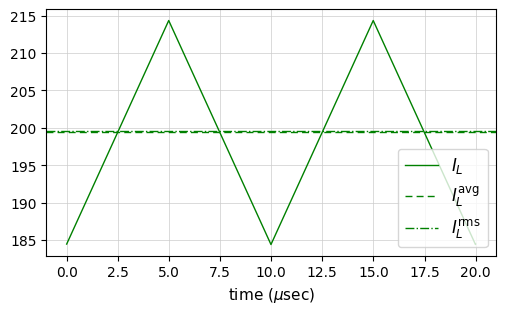

```python
import numpy as np
import matplotlib.pyplot as plt
import gseim_calc as calc
from setsize import set_size

slv = calc.slv("boost_ccm_2.in")

i_slv = 0
i_out = 0
filename = slv.l_filename_all[i_slv][i_out]
print('filename:', filename)
u = np.loadtxt(filename)
t1 = u[:, 0]
t = t1*1e6 # convert time to micro-seconds

IL = slv.get_array_double(i_slv,i_out,"IL",u)
IS = slv.get_array_double(i_slv,i_out,"IS",u)
ID = slv.get_array_double(i_slv,i_out,"ID",u)
IC = slv.get_array_double(i_slv,i_out,"IC",u)
v_in = slv.get_array_double(i_slv,i_out,"v_in",u)
v_out = slv.get_array_double(i_slv,i_out,"v_out",u)
clock = slv.get_array_double(i_slv,i_out,"clock",u)

# since we have stored two cycles, we need to divide the last time point
# by 2 to get the period:

T = t[-1]/2

color1='green'
color2='crimson'
color3='goldenrod'
color4='blue'

fig, ax = plt.subplots()
plt.subplots_adjust(wspace=0, hspace=0.0)

set_size(4, 2.5, ax)

plt.grid(color='#CCCCCC', linestyle='solid', linewidth=0.5)

l = calc.avg_rms_3a(t, IL, 0.0, 2*T, 1.0e-4*T)

ax.plot(t, IL, color=color1, linewidth=1.0, label="$I_L$")
ax.axhline(y=l[0], color=color1, linewidth=1.0, label=r"$I_L^{\mathrm{avg}}$", linestyle='--', dashes=(5,3))
ax.axhline(y=l[1], color=color1, linewidth=1.0, label=r"$I_L^{\mathrm{rms}}$", linestyle='-.')

plt.xlabel('time (' + r'$\mu$' + 'sec)', fontsize=11)

ax.legend(loc = 'lower right',frameon = True, fontsize = 10, title = None,
   markerfirst = True, markerscale = 1.0, labelspacing = 0.5, columnspacing = 2.0,
   prop = {'size' : 12},)

plt.tight_layout()
plt.show()
```

```
filename: boost_ccm_2.dat
```

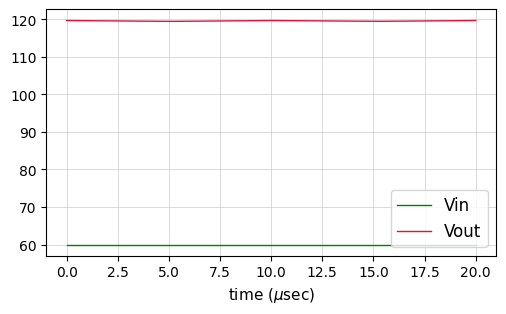

```python
import numpy as np
import matplotlib.pyplot as plt
import gseim_calc as calc
from setsize import set_size

slv = calc.slv("boost_ccm_2.in")

i_slv = 0
i_out = 0
filename = slv.l_filename_all[i_slv][i_out]
print('filename:', filename)
u = np.loadtxt(filename)
t1 = u[:, 0]
t = t1*1e6 # convert time to micro-seconds

IL = slv.get_array_double(i_slv,i_out,"IL",u)
IS = slv.get_array_double(i_slv,i_out,"IS",u)
ID = slv.get_array_double(i_slv,i_out,"ID",u)
IC = slv.get_array_double(i_slv,i_out,"IC",u)
v_in = slv.get_array_double(i_slv,i_out,"v_in",u)
v_out = slv.get_array_double(i_slv,i_out,"v_out",u)
clock = slv.get_array_double(i_slv,i_out,"clock",u)

color1='green'
color2='crimson'
color3='goldenrod'
color4='blue'

fig, ax = plt.subplots()
plt.subplots_adjust(wspace=0, hspace=0.0)

set_size(4, 2.5, ax)

plt.grid(color='#CCCCCC', linestyle='solid', linewidth=0.5)

ax.plot(t, v_in, color=color1, linewidth=1.0, label="Vin")
ax.plot(t, v_out, color=color2, linewidth=1.0, label="Vout")

plt.xlabel('time (' + r'$\mu$' + 'sec)', fontsize=11)

ax.legend(loc = 'lower right',frameon = True, fontsize = 10, title = None,
   markerfirst = True, markerscale = 1.0, labelspacing = 0.5, columnspacing = 2.0,
   prop = {'size' : 12},)

plt.tight_layout()
plt.show()
```

On the output file produced by `GSEIM` (in this case, `boost_ccm_2.dat`), we can do some post-processing to obtain average and rms values, for example. For this purpose, a python module `gseim_calc.py` has been included in the directory from which you launched Jupyter. Run the following python script to obtain the quantities of interest listed in the question.

```python
import gseim_calc as calc
import numpy as np

slv = calc.slv("boost_ccm_2.in")

i_slv = 0
i_out = 0
filename = slv.l_filename_all[i_slv][i_out]
print('filename:', filename)
u = np.loadtxt(filename)
t = u[:, 0]

IL = slv.get_array_double(i_slv,i_out,"IL",u)
IS = slv.get_array_double(i_slv,i_out,"IS",u)
ID = slv.get_array_double(i_slv,i_out,"ID",u)
IC = slv.get_array_double(i_slv,i_out,"IC",u)
v_in = slv.get_array_double(i_slv,i_out,"v_in",u)
v_out = slv.get_array_double(i_slv,i_out,"v_out",u)
clock = slv.get_array_double(i_slv,i_out,"clock",u)

T = t[-1]/2

t_start = 0.0
t_end = 2.0*T

l = calc.min_max_1(t, IL, t_start, t_end)
IL_ptop = l[1] - l[0]
print('IL_ptop:', "%11.4E"%IL_ptop)

l = calc.min_max_1(t, v_out, t_start, t_end)
VC_ptop = l[1] - l[0]
print('VC_ptop:', "%11.4E"%VC_ptop)

l = calc.avg_rms_3a(t, IL, 0.0, 2*T, 1.0e-4*T)
IL_rms = l[1]
print('IL_rms:', "%11.4E"%IL_rms)

IL_avg = l[0]
print('IL_avg:', "%11.4E"%IL_avg)

print('x (in percent):', "%5.2F"%(100*IL_ptop/IL_avg))

l = calc.avg_rms_3a(t, IS, 0.0, 2*T, 1.0e-4*T)
IS_rms = l[1]
print('IS_rms:', "%11.4E"%IS_rms)

l = calc.avg_rms_3a(t, ID, 0.0, 2*T, 1.0e-4*T)
ID_rms = l[1]
print('ID_rms:', "%11.4E"%ID_rms)

l = calc.avg_rms_3a(t, IC, 0.0, 2*T, 1.0e-4*T)
IC_rms = l[1]
print('IC_rms:', "%11.4E"%IC_rms)

l = calc.avg_rms_3a(t, v_out, 0.0, 2*T, 1.0e-4*T)
Vo_rms = l[1]
print('Vo_rms:', "%11.4E"%Vo_rms)
```

```
filename: boost_ccm_2.dat
IL_ptop:  2.9901E+01
VC_ptop:  2.2650E-01
IL_rms:  1.9958E+02
IL_avg:  1.9939E+02
x (in percent): 15.00
IS_rms:  1.4120E+02
ID_rms:  1.4105E+02
IC_rms:  9.9859E+01
Vo_rms:  1.1960E+02
```

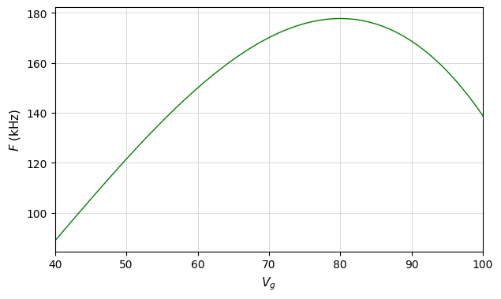

```python
import numpy as np
import matplotlib.pyplot as plt

from setsize import set_size

Vgmin = 40.0
Vgmax = 100.0
Vg = np.linspace(Vgmin, Vgmax, num=61)
L = 10.0e-6
Vo = 120.0
P = 12000.0
x = 0.1
k = 1.0/(P*x*L)
F = k*Vg*Vg*(1.0-(Vg/Vo))*1e-3 # converted to kHz

color1='green'
color2='crimson'
color3='goldenrod'
color4='blue'

fig, ax = plt.subplots()
plt.subplots_adjust(wspace=0, hspace=0.0)

set_size(5, 3.0, ax)

plt.grid(color='#CCCCCC', linestyle='solid', linewidth=0.5)

ax.plot(Vg, F, color=color1, linewidth=1.0)

ax.set_xlim(left=Vgmin, right=Vgmax)
plt.xlabel(r'$V_g$', fontsize=11)
plt.ylabel(r'$F$ (kHz)', fontsize=11)

#ax.legend(loc = 'lower right',frameon = True, fontsize = 10, title = None,
#   markerfirst = True, markerscale = 1.0, labelspacing = 0.5, columnspacing = 2.0,
#   prop = {'size' : 12},)

plt.tight_layout()
plt.show()
```

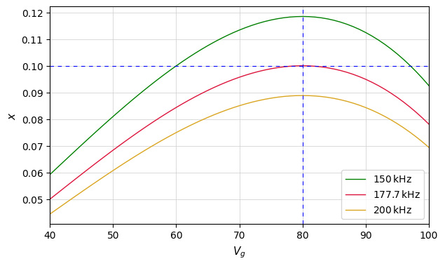

```python
import numpy as np
import matplotlib.pyplot as plt

from setsize import set_size

Vgmin = 40.0
Vgmax = 100.0
Vg = np.linspace(Vgmin, Vgmax, num=61)
F = [150.0e3, 177.7e3, 200.0e3]
label1 = [r'$150\,$kHz', r'$177.7\,$kHz', r'$200\,$kHz']
L = 10.0e-6
Vo = 120.0
P = 12000.0

color1 = ['green', 'crimson', 'goldenrod']

fig, ax = plt.subplots()
plt.subplots_adjust(wspace=0, hspace=0.0)

set_size(5, 3.0, ax)

plt.grid(color='#CCCCCC', linestyle='solid', linewidth=0.5)

ax.set_xlim(left=Vgmin, right=Vgmax)
plt.xlabel(r'$V_g$', fontsize=11)
plt.ylabel(r'$x$', fontsize=11)

for i, f1 in enumerate(F):
    k = 1.0/(P*F[i]*L)
    x = k*Vg*Vg*(1.0-(Vg/Vo))
    ax.plot(Vg, x, color=color1[i], linewidth=1.0, label=label1[i])

plt.axhline(y = 0.1, color = 'blue', linestyle = '--', linewidth=0.8, dashes=(5,5))
plt.axvline(x = 80, color = 'blue', linestyle = '--', linewidth=0.8, dashes=(5,5))

ax.legend(loc = 'lower right',frameon = True, fontsize = 10, title = None,
   markerfirst = True, markerscale = 1.0, labelspacing = 0.5, columnspacing = 2.0,
   prop = {'size' : 10},)

plt.tight_layout()
```

This notebook was contributed by **Prof. Nakul Narayanan K**, Govt. Engineering College, Thrissur. He may be contacted at nakul@gectcr.ac.in.